# SDS HW 2

2024-01-24

Name: Ankita Chitturi

EID: ac86269

GitHub Repo Link: https://github.com/ankitachitturi/SDS315_HW2.git

## Question 1

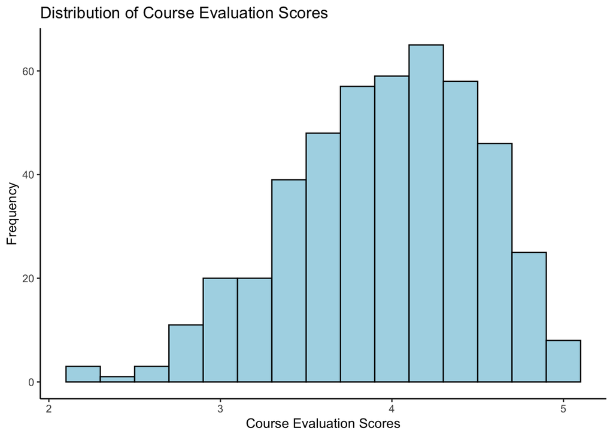

The histogram showed above analyzes course evaluation scores at UT Austin and their frequency. It can be said that the graph is skewed left/negatively, evidently showing that students believe their professors deserve a decently high evaluation score. The average score was calculated to be approximately 3.99 and the median seemingly was exactly 4.

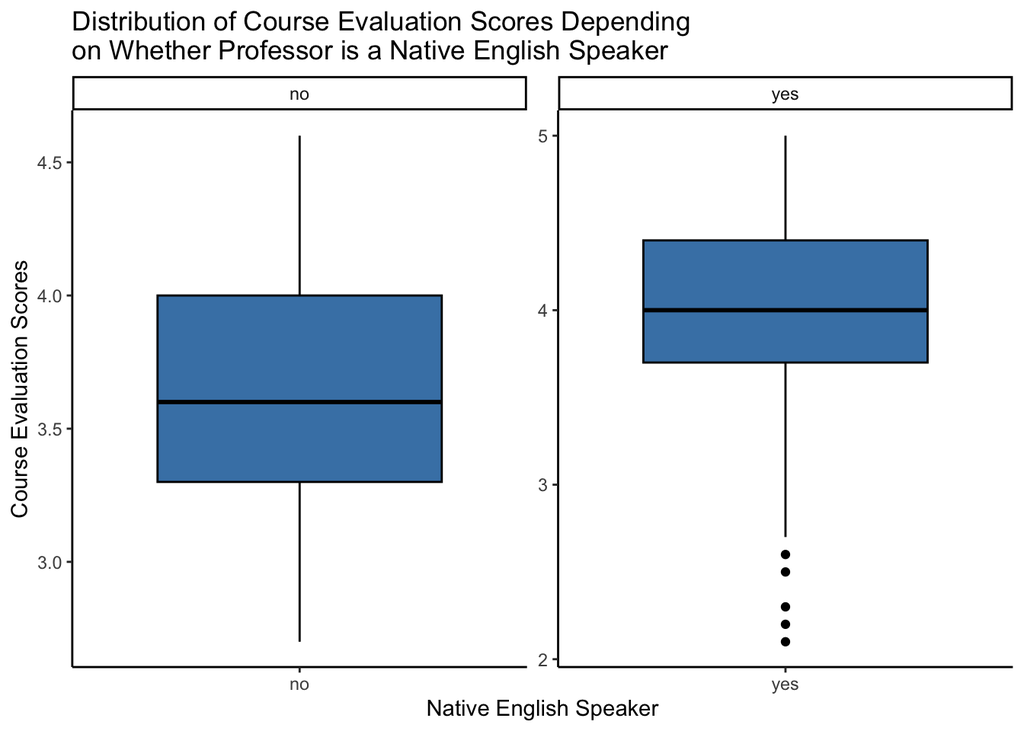

The boxplots above compare the course evaluation scores, solely dependent on whether the professor is a native English speaker. It can be concluded that professors who are native speakers tend to receive higher course evaluation scores on average; however, as expected, there are outliers.

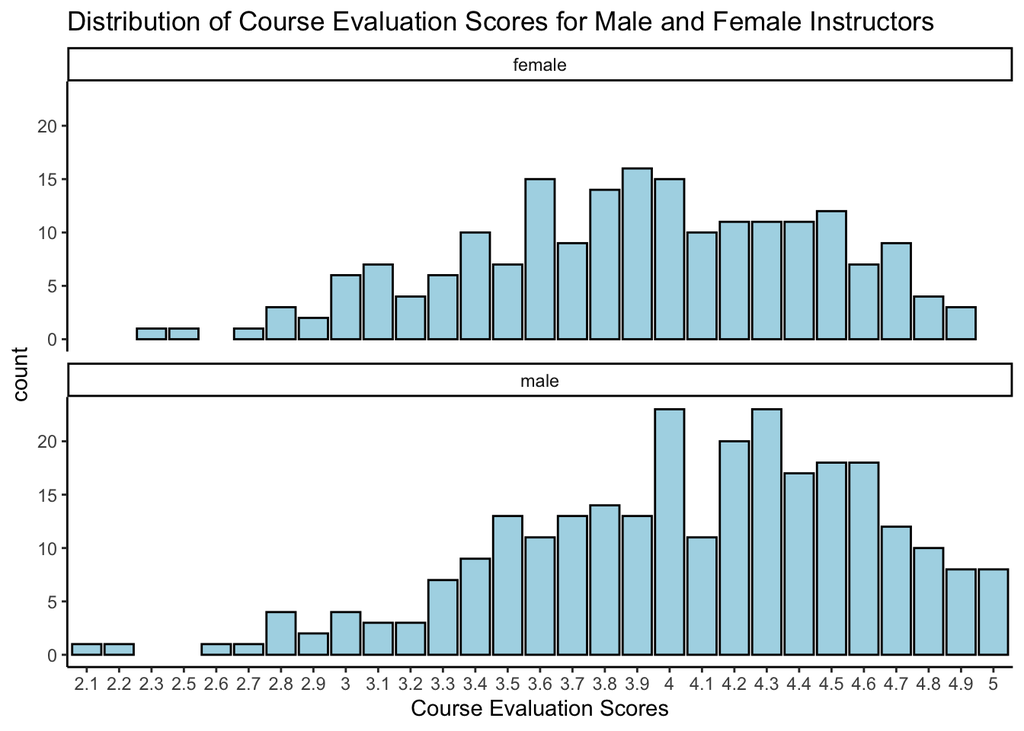

The faceted histogram above shows the distribution of course evaluation scores for male and female instructors. Based on the plots, it can be concluded that male instructors obtain higher course evaluation scores compared to their female instructors.

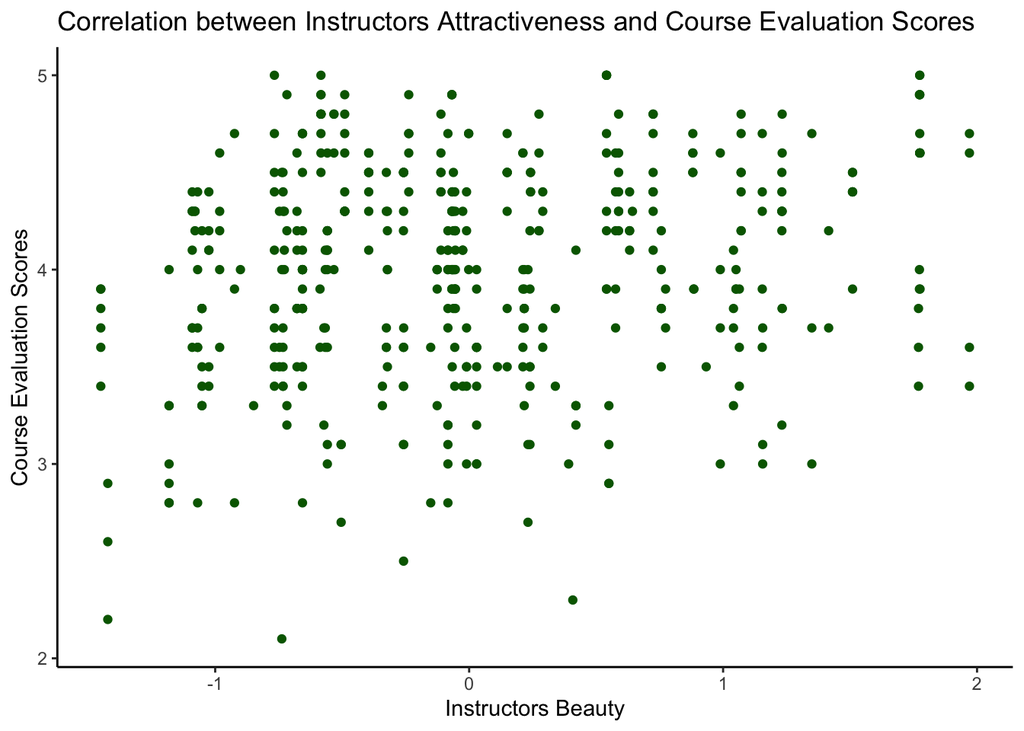

According to the scatterplot above depicting the relationship between an instructors physical attractiveness and their course evaluations, it initially seems as though there is no correlation between the two selected variables. However, after finding the correlation coefficient to be approximately 0.18, it is concluded that there is a weak positive correlation between evaluation scores and the instructor’s beauty.

## Question 2

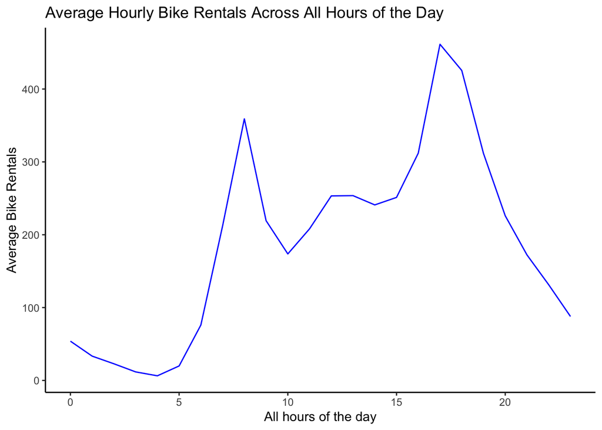

```
## [1] 461.4521
```

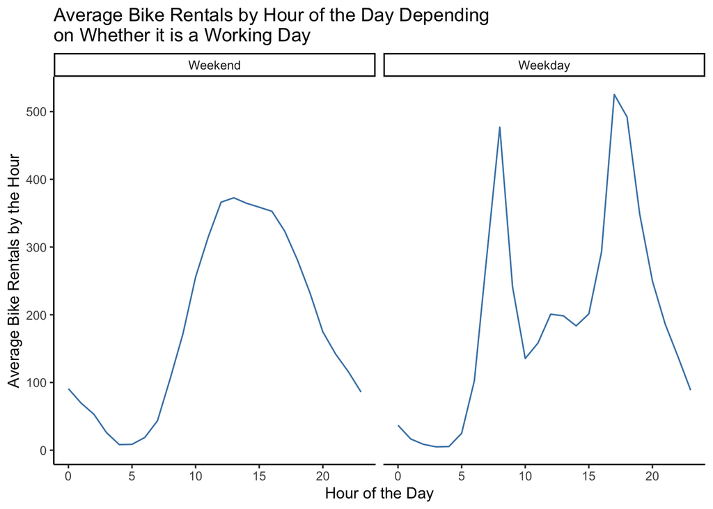

The graphs above are faceted to analyze data by whether it is a weekend or weekday. It is easy to see the average hourly bike rentals depending on the hour (for both weekend and weekday).

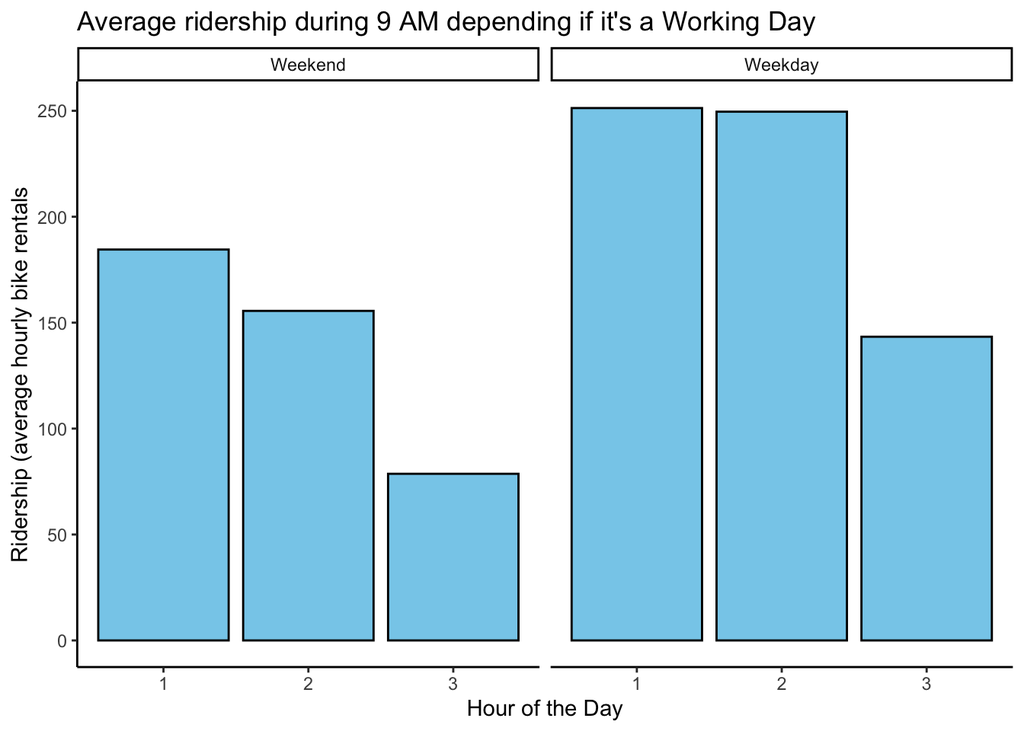

The plots above are once again faceted so one can easily analyze the data separated by the weekend and weekday. On average, it is evident that the ridership (average hourly bike rentals) is greater during the weekday then the weekend; however, it is also concluded that they’re both positively skewed.

## Question 3

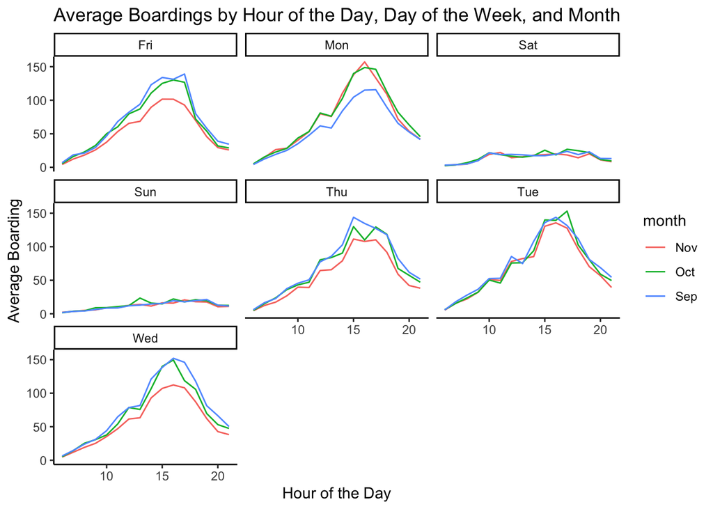

As shown by the plots above, the hour of peak boardings is seemingly similar across the weekdays. From the graphs depicting weekday data, there is an evident peak in regards to average boarding. However, both Saturday and Sunday’s average boardings are somewhat constant. Average boardings on Mondays in September tend to be slighter lower due to nationally celebrates holidays compared to other months and days. A similar occurence is spotted on Wednesday, Thursday, and Friday in November due to Thanksgiving break.

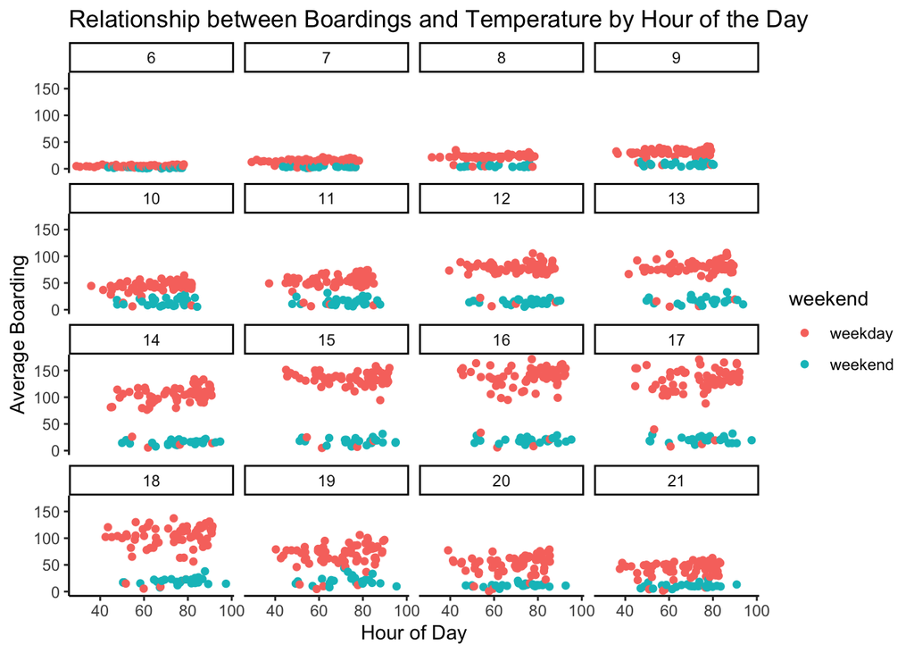

The plots shown above separate the data to visualize average boardings dependent on whether it is a weekday or weekend. Moreover, when both the hour of the day and weekend status are held constant, temperature does not seem to have a noticeable effect on the number of UT students riding the bus.

## Question 4

```
## # A tibble: 10 × 3
##    performer                                 song                          count
##    <chr>                                     <chr>                         <int>
##  1 Imagine Dragons                           Radioactive                      87
##  2 AWOLNATION                                Sail                             79
##  3 Jason Mraz                                I'm Yours                        76
##  4 The Weeknd                                Blinding Lights                  76
##  5 LeAnn Rimes                               How Do I Live                    69
##  6 LMFAO Featuring Lauren Bennett & GoonRock Party Rock Anthem                68
##  7 OneRepublic                               Counting Stars                   68
##  8 Adele                                     Rolling In The Deep              65
##  9 Jewel                                     Foolish Games/You Were Meant…    65
## 10 Carrie Underwood                          Before He Cheats                 64
```

The table given is a snapshot of the top 10 most popular songs since 1958. With the name of the song, the performer is also given. Additionally, the count (total number of weeks the song spent on the Billboard Top 100) is also shown. The songs appear in a descending order based on count, meaning that the list is read from the most to least popular (top to bottom) in regards to those specific songs.

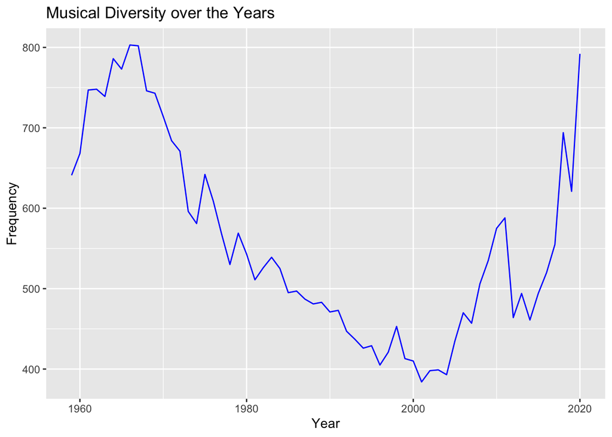

The line graph shows the number of unique songs that appeared on the Billboard Top 100 (y-axis) during any week in a year (x-axis). The years 1958 and 2021 was excluded from this graph. There is a clear downward trend towards the year 2000 and then a sudden positive/upwards trend.

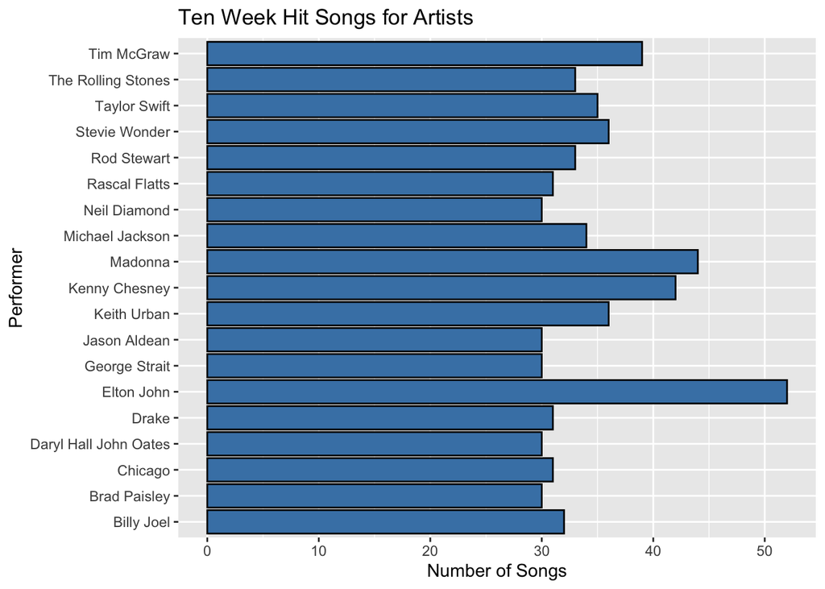

The final plot above depicts 19 performers who have had at least 30 songs that appeared on the Billboard Top 100 for at least ten weeks, commonly known as “ten-week hits”. The performer names are given on the y-axis and the number of ten-week hits each performer held was given on the x-axis. It can be easily concluded that Elton John had the most ten-week hits, surpassing 50.